# Librerias

```python
import numpy as np
import pandas as pd
import matplotlib.pyplot as plt
from matplotlib import cm
```

## Conjunto de datos

```python
df = pd.read_csv('data.csv',delimiter='\t',header=None)
X  = df.values
```

## Constantes

```python
#  TOTAL DE CLASES
C  = 3
# TOTAL DE PATRONES EN EL CONJUNTO
N  = X.shape[0]*C
# TOTAL DE DIMENENSIONES
D  = X.shape[1]//3
```

## Muestras por clase

```python
w0       = X[:,:3]
w0_class = np.repeat(0,w0.shape[0]).reshape(-1,1)
w0       = np.hstack([w0,w0_class])

w1       = X[:,3:6]
w1_class = np.repeat(1,w0.shape[0]).reshape(-1,1)
w1       = np.hstack([w1,w1_class])

w2       = X[:,6:]
w2_class = np.repeat(2,w0.shape[0]).reshape(-1,1)
w2       = np.hstack([w2,w2_class])
__X      = np.vstack([w0,w1,w2])
```

## Gráfica de las muestras

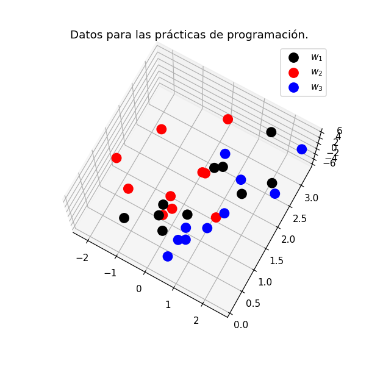

```python
%matplotlib notebook
fig = plt.figure(figsize=(5,5))
ax = fig.add_subplot(projection='3d')
ax.scatter(w0[:,0],w0[:,1],w0[:,2],color="black",s=100,alpha=1,label="$w_1$")
ax.scatter(w1[:,0],w1[:,1],w1[:,2],color="red",s=100,alpha=1,label="$w_2$")
ax.scatter(w2[:,0],w2[:,1],w2[:,2],color="blue",s=100,alpha=1,label="$w_3$")
ax.set_title("Datos para las prácticas de programación.")
ax.legend()
```

### KNN

Clasificador Knn que acepta un patrones de prueba.

```python
def knn_classifier(X,**kwargs):
    # Numero de vecinos
    k            = kwargs.get('k',1)
    # Flag para que retorne el radio el cual es la distancia entre centro(xt) al vecino mas lejano dentro de los mas cercanos
    get_radio    = kwargs.get('get_radio',False)
    # Flag para que retorne la cantidad de vecinos de una clase wi
    get_counter  = kwargs.get('get_counter',False)
    # Flag para que retorne las distancias entre xt y todas las muestras en X
    get_distance = kwargs.get('get_distance',False)
    # q is the parameter for the Lq, when q = 2 it represents the Euclidean distance, q=2 is the default value
    q           = kwargs.get('q',2)
    # D is a constant that represent the number of dimensions
    dtype    = [('distance',float),('class',int)]

    # funcion para aplicar una funcion de distancia entre un vector de patrones y un patron de prueba
    def __fn(center,**kwargs):
        q              = kwargs.get('q',2)
        def _fn(xt):
            xi    = xt[:3]
            klass = int(xt[-1])
            distance_val = Lq(center,q=q)(xi.reshape(1,xi.shape[0]))[0]
            return (distance_val,klass)
        return _fn
    # Funcion que se retorna, la cual recibe un patron de prueba
    def __knn_classifier(center):
        result   = list(map(__fn(center,q=q),X ))
        result   = np.array(result,dtype = dtype)
        knearest = np.sort(result,order='distance')
        knearest = knearest[:k]
#         print("DISTANCE: ",knearest[0][0])
        keys     = list(map(lambda i:(i,0) ,range(C)  ))
        counter  = dict(keys)
        for (distance,klass) in knearest:
            counter[klass]+=1
        klass =np.argmax(list(counter.values()))
        if get_radio:
            return knearest[-1][0]
        elif get_counter:
            return counter
        elif get_distance:
            return klass,list(map(lambda x:x[0],knearest))
        else:
            return klass
    return __knn_classifier
```

Clasificador Knn que acepta un arreglo de patrones de prueba.

```python
def knn_classifierS(X,**kwargs):
    k      = kwargs.get('k',1)
    q      = kwargs.get('q',2)
    XT     = kwargs.get('XT')
    get_radios = kwargs.get('get_radio',False)
    result = []
    for xt in XT:
        result.append(knn_classifier(X,k=k,get_radio=get_radios,q=q)(xt))
    return np.array(result)
```

# Práctica 1

Considere las estimaciones de densidad usando los k-vecinos más cercanos (kNN) en diferente número de dimensiones. Se utilizarán los datos mostrados en la Tabla 1.

### Práctica1a

a) Escriba un programa para la estimación de densidad kNN de n puntos en d dimensiones, de acuerdo con la Ecuación 15, de la clase AD-05.

$p(x) = \frac{k}{nV}$

```python
def knn_px_est(**kwargs):
    # k is the number of the nearest datapoints.
    k = kwargs.get('k',1)
    # N is a constant that represents the total number of patterns in the training set.
    n = kwargs.get('n',N)
#     V = kwargs.get('V',1)
    return lambda V: k/(n*V)
```

### V0

El volumen esta dado por la siguiente fórmula: $V = V_0 \cdot r^{d}$

```python
def knn_V(r,**kwargs):
    __factorial = np.math.factorial
    # D is a constant that represent the number of dimensions
    d   = kwargs.get('d',D)
    Vo  = knn_V0(d)
    return Vo*np.power(r,d)
```

### V

El volumen unitario estado dado por la siguiente fórmula:

$ V_0 = \begin{cases} \pi^{d/2} / (d/2)!, & \text{si }d\text{ es par} \\ 2^{d} \pi^{d-1}/2 (\frac{d-1}{2}!) / d!, & \text{si }d\text{ es impar} \end{cases} $

```python
def knn_V0(d):
    __factorial = np.math.factorial
    fn1 = np.power(np.pi,d//2)/__factorial(d//2)
    fn2 = (np.power(2,d) * np.power(np.pi,(d-1)//2)*__factorial((d-1)//2))/__factorial(d)
    return fn1 if(d%2 ==0) else fn2
```

### Práctica1b

b) Use su programa para $k = [1, 3, 5, 7]$ para estimar la densidad relativa en los siguientes puntos para cada una de las clases $\omega_i$, $i = 1, 2, 3$: $(−0.41, 0.82, 0.88)^T$,$(0.14,0.72, 4.1)^T$, y $(−0.81, 0.61, −0.38)^T$.Utilice la regla de máxima probabilidad para clasificar estos puntos (Clase AD-05, Ecuación 14).

```python
patterns = np.array([ [-.41,.82,.88],[.14,.72,4.1],[-.81,.61,-.38] ])
ks=[1,3,5,7]
# Funcion que calcula la densidad relativa de los patrones para diferentes valores de k
def printPractica1b(k):
    for i,xt in enumerate(patterns):
        result = []
        for j,wi in enumerate([w0,w1,w2]):
            r  = knn_classifier(wi,k=k,q=2,get_radio=True)(xt)
            V  = knn_V(r)
            px = knn_px_est(k=k,n=wi.shape[0])(V)
            print("Estimación de densidad para clase w{}: \t p(x{})={}".format(j,i,px))
            result.append(px)
        print("*"*100)
        reuslt = np.array(result)
        klass  = np.argmax(result)
        print("\t\t\t x{}={} clasificado como w{}\t".format(i,xt,klass))
        print("*"*100)
    print("\n\n")
```

$ k = 1 $

```python
printPractica1b(ks[0])
```

```
Estimación de densidad para clase w0: 	 p(x0)=0.004496038562875202
Estimación de densidad para clase w1: 	 p(x0)=0.052920490450730516
Estimación de densidad para clase w2: 	 p(x0)=0.018411273182967182
			 x0=[-0.41  0.82  0.88] clasificado como w1
Estimación de densidad para clase w0: 	 p(x1)=0.00986421070828497
Estimación de densidad para clase w1: 	 p(x1)=0.00039036321658372027
Estimación de densidad para clase w2: 	 p(x1)=0.0007332961908026208
			 x1=[0.14 0.72 4.1 ] clasificado como w0
Estimación de densidad para clase w0: 	 p(x2)=0.04229415330689815
Estimación de densidad para clase w1: 	 p(x2)=0.032310162504864896
Estimación de densidad para clase w2: 	 p(x2)=0.0032763444870310505
			 x2=[-0.81  0.61 -0.38] clasificado como w0
```

$k = 3 $

```python
printPractica1b(ks[1])
```

```
Estimación de densidad para clase w0: 	 p(x0)=0.002099881727800167
Estimación de densidad para clase w1: 	 p(x0)=0.05529658657003885
Estimación de densidad para clase w2: 	 p(x0)=0.03583359763447283
			 x0=[-0.41  0.82  0.88] clasificado como w1
Estimación de densidad para clase w0: 	 p(x1)=0.004288681289489949
Estimación de densidad para clase w1: 	 p(x1)=0.0009647806082390033
Estimación de densidad para clase w2: 	 p(x1)=0.002051156987260027
			 x1=[0.14 0.72 4.1 ] clasificado como w0
Estimación de densidad para clase w0: 	 p(x2)=0.002632811635519811
Estimación de densidad para clase w1: 	 p(x2)=0.08685536725221907
Estimación de densidad para clase w2: 	 p(x2)=0.008454995723137862
			 x2=[-0.81  0.61 -0.38] clasificado como w1
```

$k=5$

```python
printPractica1b(ks[2])
```

```
Estimación de densidad para clase w0: 	 p(x0)=0.002614944210445274
Estimación de densidad para clase w1: 	 p(x0)=0.03327664673353169
Estimación de densidad para clase w2: 	 p(x0)=0.026581112078461734
			 x0=[-0.41  0.82  0.88] clasificado como w1
Estimación de densidad para clase w0: 	 p(x1)=0.0010255387557116637
Estimación de densidad para clase w1: 	 p(x1)=0.0015492533215585842
Estimación de densidad para clase w2: 	 p(x1)=0.0025860992739860835
			 x1=[0.14 0.72 4.1 ] clasificado como w2
Estimación de densidad para clase w0: 	 p(x2)=0.0018676527558116678
Estimación de densidad para clase w1: 	 p(x2)=0.029813898753325307
Estimación de densidad para clase w2: 	 p(x2)=0.0094855259161561
			 x2=[-0.81  0.61 -0.38] clasificado como w1
```

$k=7$

```python
printPractica1b(ks[3])
```

```
Estimación de densidad para clase w0: 	 p(x0)=0.0014164857880057812
Estimación de densidad para clase w1: 	 p(x0)=0.02373016198402808
Estimación de densidad para clase w2: 	 p(x0)=0.013708084401366937
			 x0=[-0.41  0.82  0.88] clasificado como w1
Estimación de densidad para clase w0: 	 p(x1)=0.0012771644005114533
Estimación de densidad para clase w1: 	 p(x1)=0.0019075560496961048
Estimación de densidad para clase w2: 	 p(x1)=0.00278488133018206
			 x1=[0.14 0.72 4.1 ] clasificado como w2
Estimación de densidad para clase w0: 	 p(x2)=0.0012228248873940824
Estimación de densidad para clase w1: 	 p(x2)=0.029283936016656832
Estimación de densidad para clase w2: 	 p(x2)=0.008971281836017262
			 x2=[-0.81  0.61 -0.38] clasificado como w1
```

## Práctica 2

Explore el efecto de la medición de distancia del clasificador 1NN al utilizar diferentes valores de q en la norma $L_q$ o métrica Minkowski:

```python
def Lq(a,**kwargs):
    npower = np.power
    _q = kwargs.get('q',1)
    def __Lq(b,**kwargs):
        q = kwargs.get('q',_q)
        if q == np.inf:
            return (distance1(a)(b)).flatten()
        res =  npower( npower(np.abs(a-b),q).sum(axis=1) ,1/q )
        return res

    return __Lq
```

### Práctica2a

a) Escriba un programa que implemente el clasificador 1NN para $c$ clases, usando la norma $L_q$, donde $q$ puede variarse.

```python
oneKnn    = lambda q : knn_classifier(__X, k=1,q=q,get_distance=True)
```

### Práctica2b

b) Use las muestras tridimensionales de la Tabla 1 para clasificar los siguientes puntos usando la norma $L_q$ para $q =$ $(1/2, 1, 2, \infty)$: $(2.21, 1.9, 0.43)^T$,$(−0.5, 1.17, 6.19)^T$ , y $(0.01, 1.34, 2.60)^T$.

```python
qs       = [0.5,1,2,np.inf]
patterns = np.array([[2.21,1.9,0.43],[-.5,1.17,6.19],[0.01,1.34,2.60]])
for q in qs:
    print("*"*10,'q={}'.format(q),"*"*10)
    for xt in patterns:
        klass,distance = oneKnn(q)(xt)
        print("{} clasificado como w{}\t\t- distance = {}".format(xt,klass,distance[0]))
    print("*"*100)
```

```
********** q=0.5 **********
[2.21 1.9  0.43] clasificado como w0		- distance = 2.5873077738250645
[-0.5   1.17  6.19] clasificado como w0		- distance = 4.867989164144127
[0.01 1.34 2.6 ] clasificado como w1		- distance = 5.128887261835705
********** q=1 **********
[2.21 1.9  0.43] clasificado como w0		- distance = 1.15
[-0.5   1.17  6.19] clasificado como w0		- distance = 1.73
[0.01 1.34 2.6 ] clasificado como w2		- distance = 2.95
********** q=2 **********
[2.21 1.9  0.43] clasificado como w0		- distance = 0.8092589202474076
[-0.5   1.17  6.19] clasificado como w0		- distance = 1.1087380213558116
[0.01 1.34 2.6 ] clasificado como w2		- distance = 1.9350193797479136
********** q=inf **********
[2.21 1.9  0.43] clasificado como w0		- distance = 0.62
[-0.5   1.17  6.19] clasificado como w0		- distance = 0.96
[0.01 1.34 2.6 ] clasificado como w2		- distance = 1.61
```

```python
disFn = Lq(__X[:,:3])
distances = []
for q in qs:
    for xt in patterns:
        d = np.array(disFn(xt,q=q))
        distances.append(np.concatenate([ [q],d] ))

ddf  = pd.DataFrame(distances)
ddf.rename(columns={0:'q'},inplace=True)
q05  = ddf[ddf['q']==.5]
q1   = ddf[ddf['q']==1]
q2   = ddf[ddf['q']==2]
qinf = ddf[ddf['q']==np.inf]
# q05.iloc[0][1:].values.min()
# ddf
```

```python
def displayDistance(D):
    for xt,d in zip(__X[:,:3],D):
        print('Lq({},xt) \t= {}'.format(xt,d))
```

$xt = (2.21, 1.9, 0.43)^T$

$L_{0.5}(xt,x)$, donde $x \in X$ (conjunto de muestras)

```python
displayDistance(q05.iloc[0].values[1:])
```

```
Lq([ 0.28  1.31 -6.2 ],xt) 	= 22.394072813101527
Lq([ 0.07  0.58 -0.78],xt) 	= 13.777358376773568
Lq([ 1.54  2.01 -1.63],xt) 	= 6.684643567285099
Lq([-0.44  1.18 -4.32],xt) 	= 21.677029255597223
Lq([-0.81  0.21  5.73],xt) 	= 28.515467635891984
Lq([1.52 3.16 2.77],xt) 	= 12.130351787397094
Lq([ 2.2   2.42 -0.19],xt) 	= 2.5873077738250645
Lq([0.91 1.94 6.21],xt) 	= 14.020070661296375
Lq([0.65 1.93 4.38],xt) 	= 11.625817948141293
Lq([-0.26  0.82 -0.96],xt) 	= 14.362860403752553
Lq([ 0.011  1.03  -0.21 ],xt) 	= 10.340343596809278
Lq([1.27 1.28 0.08],xt) 	= 5.515662382603554
Lq([0.13 3.12 0.16],xt) 	= 9.402636348076536
Lq([-0.21  1.23 -0.11],xt) 	= 9.665987443950574
Lq([-2.18  1.39 -0.19],xt) 	= 12.936799854614303
Lq([ 0.34  1.96 -0.16],xt) 	= 5.666984890020316
Lq([-1.38  0.94  0.45],xt) 	= 9.095935012969123
Lq([-0.12  0.82  0.17],xt) 	= 9.459107377679096
Lq([-1.44  2.31  0.14],xt) 	= 9.54393650538699
Lq([0.26 1.94 0.08],xt) 	= 4.787483957260574
Lq([1.36 2.17 0.14],xt) 	= 3.9207412355301208
Lq([ 1.41  1.45 -0.38],xt) 	= 6.077445651649734
Lq([1.22 0.99 0.69],xt) 	= 6.045838034425257
Lq([2.46 2.19 1.31],xt) 	= 3.9069461079033436
Lq([0.68 0.79 0.87],xt) 	= 8.72506453199059
Lq([2.51 3.22 1.35],xt) 	= 7.053281030962222
Lq([0.6  2.44 0.92],xt) 	= 7.310018979782274
Lq([0.64 0.13 0.97],xt) 	= 11.01082819747651
Lq([0.85 0.58 0.99],xt) 	= 9.384630235069165
Lq([0.66 0.51 0.88],xt) 	= 9.577743498094938
```

$xt = (−0.5, 1.17, 6.19)^T$

$L_{0.5}(xt,x)$, donde $x \in X$ (conjunto de muestras)

```python
displayDistance(q05.iloc[1].values[1:])
```

```
Lq([ 0.28  1.31 -6.2 ],xt) 	= 22.82245203495195
Lq([ 0.07  0.58 -0.78],xt) 	= 17.332015879205404
Lq([ 1.54  2.01 -1.63],xt) 	= 26.432216253375074
Lq([-0.44  1.18 -4.32],xt) 	= 12.865578933640906
Lq([-0.81  0.21  5.73],xt) 	= 4.905362657365728
Lq([1.52 3.16 2.77],xt) 	= 21.914240494846958
Lq([ 2.2   2.42 -0.19],xt) 	= 27.953086443402146
Lq([0.91 1.94 6.21],xt) 	= 4.867989164144127
Lq([0.65 1.93 4.38],xt) 	= 10.82095974442192
Lq([-0.26  0.82 -0.96],xt) 	= 14.103437136768902
Lq([ 0.011  1.03  -0.21 ],xt) 	= 13.095934237225416
Lq([1.27 1.28 0.08],xt) 	= 17.089272801005624
Lq([0.13 3.12 0.16],xt) 	= 21.583041650178107
Lq([-0.21  1.23 -0.11],xt) 	= 10.846783489337126
Lq([-2.18  1.39 -0.19],xt) 	= 18.41316076890977
Lq([ 0.34  1.96 -0.16],xt) 	= 18.70783266963866
Lq([-1.38  0.94  0.45],xt) 	= 14.542751852135622
Lq([-0.12  0.82  0.17],xt) 	= 13.40744790030704
Lq([-1.44  2.31  0.14],xt) 	= 20.222276642624408
Lq([0.26 1.94 0.08],xt) 	= 17.81783418398125
Lq([1.36 2.17 0.14],xt) 	= 23.266084189966545
Lq([ 1.41  1.45 -0.38],xt) 	= 20.020066378942165
Lq([1.22 0.99 0.69],xt) 	= 16.654231693364608
Lq([2.46 2.19 1.31],xt) 	= 24.398539239139346
Lq([0.68 0.79 0.87],xt) 	= 16.073940976048267
Lq([2.51 3.22 1.35],xt) 	= 28.801654187608847
Lq([0.6  2.44 0.92],xt) 	= 19.993415024780127
Lq([0.64 0.13 0.97],xt) 	= 19.11651461961949
Lq([0.85 0.58 0.99],xt) 	= 17.727134940803747
Lq([0.66 0.51 0.88],xt) 	= 17.58779510236278
```

$xt = (0.01, 1.34, 2.60)^T$

$L_{0.5}(xt,x)$, donde $x \in X$ (conjunto de muestras)

```python
displayDistance(q05.iloc[2].values[1:])
```

```
Lq([ 0.28  1.31 -6.2 ],xt) 	= 13.390474425172844
Lq([ 0.07  0.58 -0.78],xt) 	= 8.733244831560938
Lq([ 1.54  2.01 -1.63],xt) 	= 16.909887375902837
Lq([-0.44  1.18 -4.32],xt) 	= 13.700433625439151
Lq([-0.81  0.21  5.73],xt) 	= 13.970653185074086
Lq([1.52 3.16 2.77],xt) 	= 8.941325293924516
Lq([ 2.2   2.42 -0.19],xt) 	= 17.551278915499257
Lq([0.91 1.94 6.21],xt) 	= 13.128157721379495
Lq([0.65 1.93 4.38],xt) 	= 8.4232348938323
Lq([-0.26  0.82 -0.96],xt) 	= 9.781392132683184
Lq([ 0.011  1.03  -0.21 ],xt) 	= 5.128887261835705
Lq([1.27 1.28 0.08],xt) 	= 8.731416144383843
Lq([0.13 3.12 0.16],xt) 	= 10.514626638656729
Lq([-0.21  1.23 -0.11],xt) 	= 5.987377446699254
Lq([-2.18  1.39 -0.19],xt) 	= 11.382532953417776
Lq([ 0.34  1.96 -0.16],xt) 	= 9.139628344825171
Lq([-1.38  0.94  0.45],xt) 	= 10.743487561619883
Lq([-0.12  0.82  0.17],xt) 	= 6.972298919135135
Lq([-1.44  2.31  0.14],xt) 	= 14.118685651000346
Lq([0.26 1.94 0.08],xt) 	= 8.191315639710544
Lq([1.36 2.17 0.14],xt) 	= 13.25962700898083
Lq([ 1.41  1.45 -0.38],xt) 	= 10.505027949617686
Lq([1.22 0.99 0.69],xt) 	= 9.447235029603759
Lq([2.46 2.19 1.31],xt) 	= 13.126010884228332
Lq([0.68 0.79 0.87],xt) 	= 8.26821137802984
Lq([2.51 3.22 1.35],xt) 	= 16.567372527019675
Lq([0.6  2.44 0.92],xt) 	= 9.691214554109036
Lq([0.64 0.13 0.97],xt) 	= 10.051689329445992
Lq([0.85 0.58 0.99],xt) 	= 9.346182519496091
Lq([0.66 0.51 0.88],xt) 	= 9.173367981337131
```

$xt = (2.21, 1.9, 0.43)^T$

$L_{1}(xt,x)$, donde $x \in X$ (conjunto de muestras)

```python
displayDistance(q1.iloc[0].values[1:])
```

```
Lq([ 0.28  1.31 -6.2 ],xt) 	= 9.149999999999999
Lq([ 0.07  0.58 -0.78],xt) 	= 4.67
Lq([ 1.54  2.01 -1.63],xt) 	= 2.84
Lq([-0.44  1.18 -4.32],xt) 	= 8.120000000000001
Lq([-0.81  0.21  5.73],xt) 	= 10.010000000000002
Lq([1.52 3.16 2.77],xt) 	= 4.29
Lq([ 2.2   2.42 -0.19],xt) 	= 1.15
Lq([0.91 1.94 6.21],xt) 	= 7.12
Lq([0.65 1.93 4.38],xt) 	= 5.54
Lq([-0.26  0.82 -0.96],xt) 	= 4.9399999999999995
Lq([ 0.011  1.03  -0.21 ],xt) 	= 3.709
Lq([1.27 1.28 0.08],xt) 	= 1.9099999999999997
Lq([0.13 3.12 0.16],xt) 	= 3.5700000000000003
Lq([-0.21  1.23 -0.11],xt) 	= 3.63
Lq([-2.18  1.39 -0.19],xt) 	= 5.5200000000000005
Lq([ 0.34  1.96 -0.16],xt) 	= 2.52
Lq([-1.38  0.94  0.45],xt) 	= 4.57
Lq([-0.12  0.82  0.17],xt) 	= 3.67
Lq([-1.44  2.31  0.14],xt) 	= 4.3500000000000005
Lq([0.26 1.94 0.08],xt) 	= 2.34
Lq([1.36 2.17 0.14],xt) 	= 1.41
Lq([ 1.41  1.45 -0.38],xt) 	= 2.06
Lq([1.22 0.99 0.69],xt) 	= 2.1599999999999997
Lq([2.46 2.19 1.31],xt) 	= 1.4200000000000002
Lq([0.68 0.79 0.87],xt) 	= 3.0799999999999996
Lq([2.51 3.22 1.35],xt) 	= 2.54
Lq([0.6  2.44 0.92],xt) 	= 2.64
Lq([0.64 0.13 0.97],xt) 	= 3.88
Lq([0.85 0.58 0.99],xt) 	= 3.2399999999999998
Lq([0.66 0.51 0.88],xt) 	= 3.3899999999999997
```

$xt = (−0.5, 1.17, 6.19)^T$

$L_{1}(xt,x)$, donde $x \in X$ (conjunto de muestras)

```python
displayDistance(q1.iloc[1].values[1:])
```

```
Lq([ 0.28  1.31 -6.2 ],xt) 	= 13.31
Lq([ 0.07  0.58 -0.78],xt) 	= 8.13
Lq([ 1.54  2.01 -1.63],xt) 	= 10.7
Lq([-0.44  1.18 -4.32],xt) 	= 10.580000000000002
Lq([-0.81  0.21  5.73],xt) 	= 1.73
Lq([1.52 3.16 2.77],xt) 	= 7.43
Lq([ 2.2   2.42 -0.19],xt) 	= 10.330000000000002
Lq([0.91 1.94 6.21],xt) 	= 2.1999999999999997
Lq([0.65 1.93 4.38],xt) 	= 3.7200000000000006
Lq([-0.26  0.82 -0.96],xt) 	= 7.74
Lq([ 0.011  1.03  -0.21 ],xt) 	= 7.051
Lq([1.27 1.28 0.08],xt) 	= 7.99
Lq([0.13 3.12 0.16],xt) 	= 8.61
Lq([-0.21  1.23 -0.11],xt) 	= 6.65
Lq([-2.18  1.39 -0.19],xt) 	= 8.280000000000001
Lq([ 0.34  1.96 -0.16],xt) 	= 7.98
Lq([-1.38  0.94  0.45],xt) 	= 6.85
Lq([-0.12  0.82  0.17],xt) 	= 6.75
Lq([-1.44  2.31  0.14],xt) 	= 8.13
Lq([0.26 1.94 0.08],xt) 	= 7.640000000000001
Lq([1.36 2.17 0.14],xt) 	= 8.91
Lq([ 1.41  1.45 -0.38],xt) 	= 8.76
Lq([1.22 0.99 0.69],xt) 	= 7.4
Lq([2.46 2.19 1.31],xt) 	= 8.860000000000001
Lq([0.68 0.79 0.87],xt) 	= 6.880000000000001
Lq([2.51 3.22 1.35],xt) 	= 9.9
Lq([0.6  2.44 0.92],xt) 	= 7.640000000000001
Lq([0.64 0.13 0.97],xt) 	= 7.4
Lq([0.85 0.58 0.99],xt) 	= 7.140000000000001
Lq([0.66 0.51 0.88],xt) 	= 7.130000000000001
```

$xt = (0.01, 1.34, 2.60)^T$

$L_{1}(xt,x)$, donde $x \in X$ (conjunto de muestras)

```python
displayDistance(q1.iloc[2].values[1:])
```

```
Lq([ 0.28  1.31 -6.2 ],xt) 	= 9.100000000000001
Lq([ 0.07  0.58 -0.78],xt) 	= 4.2
Lq([ 1.54  2.01 -1.63],xt) 	= 6.43
Lq([-0.44  1.18 -4.32],xt) 	= 7.53
Lq([-0.81  0.21  5.73],xt) 	= 5.08
Lq([1.52 3.16 2.77],xt) 	= 3.5
Lq([ 2.2   2.42 -0.19],xt) 	= 6.0600000000000005
Lq([0.91 1.94 6.21],xt) 	= 5.109999999999999
Lq([0.65 1.93 4.38],xt) 	= 3.01
Lq([-0.26  0.82 -0.96],xt) 	= 4.3500000000000005
Lq([ 0.011  1.03  -0.21 ],xt) 	= 3.121
Lq([1.27 1.28 0.08],xt) 	= 3.84
Lq([0.13 3.12 0.16],xt) 	= 4.34
Lq([-0.21  1.23 -0.11],xt) 	= 3.04
Lq([-2.18  1.39 -0.19],xt) 	= 5.029999999999999
Lq([ 0.34  1.96 -0.16],xt) 	= 3.71
Lq([-1.38  0.94  0.45],xt) 	= 3.94
Lq([-0.12  0.82  0.17],xt) 	= 3.08
Lq([-1.44  2.31  0.14],xt) 	= 4.88
Lq([0.26 1.94 0.08],xt) 	= 3.37
Lq([1.36 2.17 0.14],xt) 	= 4.64
Lq([ 1.41  1.45 -0.38],xt) 	= 4.49
Lq([1.22 0.99 0.69],xt) 	= 3.47
Lq([2.46 2.19 1.31],xt) 	= 4.59
Lq([0.68 0.79 0.87],xt) 	= 2.95
Lq([2.51 3.22 1.35],xt) 	= 5.63
Lq([0.6  2.44 0.92],xt) 	= 3.37
Lq([0.64 0.13 0.97],xt) 	= 3.4699999999999998
Lq([0.85 0.58 0.99],xt) 	= 3.21
Lq([0.66 0.51 0.88],xt) 	= 3.2
```

$xt = (2.21, 1.9, 0.43)^T$

$L_{2}(xt,x)$, donde $x \in X$ (conjunto de muestras)

```python
displayDistance(q2.iloc[0].values[1:])
```

```
Lq([ 0.28  1.31 -6.2 ],xt) 	= 6.930360740971569
Lq([ 0.07  0.58 -0.78],xt) 	= 2.7903583999192647
Lq([ 1.54  2.01 -1.63],xt) 	= 2.1690089902994867
Lq([-0.44  1.18 -4.32],xt) 	= 5.486656541100418
Lq([-0.81  0.21  5.73],xt) 	= 6.329810423701487
Lq([1.52 3.16 2.77],xt) 	= 2.745778578108584
Lq([ 2.2   2.42 -0.19],xt) 	= 0.8092589202474076
Lq([0.91 1.94 6.21],xt) 	= 5.92452529743945
Lq([0.65 1.93 4.38],xt) 	= 4.246998940428406
Lq([-0.26  0.82 -0.96],xt) 	= 3.033051268936943
Lq([ 0.011  1.03  -0.21 ],xt) 	= 2.44991857007534
Lq([1.27 1.28 0.08],xt) 	= 1.1791946404220126
Lq([0.13 3.12 0.16],xt) 	= 2.4264583243896856
Lq([-0.21  1.23 -0.11],xt) 	= 2.568443108188305
Lq([-2.18  1.39 -0.19],xt) 	= 4.462801810522175
Lq([ 0.34  1.96 -0.16],xt) 	= 1.96178490156286
Lq([-1.38  0.94  0.45],xt) 	= 3.716194289861605
Lq([-0.12  0.82  0.17],xt) 	= 2.581259382549534
Lq([-1.44  2.31  0.14],xt) 	= 3.6843859732661017
Lq([0.26 1.94 0.08],xt) 	= 1.981565038044424
Lq([1.36 2.17 0.14],xt) 	= 0.9378166132032423
Lq([ 1.41  1.45 -0.38],xt) 	= 1.22417319036156
Lq([1.22 0.99 0.69],xt) 	= 1.369598481307569
Lq([2.46 2.19 1.31],xt) 	= 0.9596874491208064
Lq([0.68 0.79 0.87],xt) 	= 1.9407730418572904
Lq([2.51 3.22 1.35],xt) 	= 1.6367040050051813
Lq([0.6  2.44 0.92],xt) 	= 1.7674275091216611
Lq([0.64 0.13 0.97],xt) 	= 2.426808603907609
Lq([0.85 0.58 0.99],xt) 	= 1.9762590923257
Lq([0.66 0.51 0.88],xt) 	= 2.130046947839413
```

$xt = (−0.5, 1.17, 6.19)^T$

$L_{2}(xt,x)$, donde $x \in X$ (conjunto de muestras)

```python
displayDistance(q2.iloc[1].values[1:])
```

```
Lq([ 0.28  1.31 -6.2 ],xt) 	= 12.415317152614348
Lq([ 0.07  0.58 -0.78],xt) 	= 7.01811228180342
Lq([ 1.54  2.01 -1.63],xt) 	= 8.125244611702469
Lq([-0.44  1.18 -4.32],xt) 	= 10.510176021361394
Lq([-0.81  0.21  5.73],xt) 	= 1.1087380213558116
Lq([1.52 3.16 2.77],xt) 	= 4.44262309902607
Lq([ 2.2   2.42 -0.19],xt) 	= 7.039666185267595
Lq([0.91 1.94 6.21],xt) 	= 1.6066735822811056
Lq([0.65 1.93 4.38],xt) 	= 2.2751263701166144
Lq([-0.26  0.82 -0.96],xt) 	= 7.162583332848562
Lq([ 0.011  1.03  -0.21 ],xt) 	= 6.421893879534292
Lq([1.27 1.28 0.08],xt) 	= 6.362161582355482
Lq([0.13 3.12 0.16],xt) 	= 6.3686968839787
Lq([-0.21  1.23 -0.11],xt) 	= 6.306956476780224
Lq([-2.18  1.39 -0.19],xt) 	= 6.601151414715467
Lq([ 0.34  1.96 -0.16],xt) 	= 6.453851563214017
Lq([-1.38  0.94  0.45],xt) 	= 5.811617674967961
Lq([-0.12  0.82  0.17],xt) 	= 6.042127108891372
Lq([-1.44  2.31  0.14],xt) 	= 6.227816631854217
Lq([0.26 1.94 0.08],xt) 	= 6.205046333428945
Lq([1.36 2.17 0.14],xt) 	= 6.407971597939555
Lq([ 1.41  1.45 -0.38],xt) 	= 6.847729550734316
Lq([1.22 0.99 0.69],xt) 	= 5.765483500973704
Lq([2.46 2.19 1.31],xt) 	= 5.797965160295464
Lq([0.68 0.79 0.87],xt) 	= 5.462526887805679
Lq([2.51 3.22 1.35],xt) 	= 6.057078503701268
Lq([0.6  2.44 0.92],xt) 	= 5.5313470330471946
Lq([0.64 0.13 0.97],xt) 	= 5.443307817862224
Lq([0.85 0.58 0.99],xt) 	= 5.4046831544504075
Lq([0.66 0.51 0.88],xt) 	= 5.4751529658996745
```

$xt = (0.01, 1.34, 2.60)^T$

$L_{2}(xt,x)$, donde $x \in X$ (conjunto de muestras)

```python
displayDistance(q2.iloc[2].values[1:])
```

```
Lq([ 0.28  1.31 -6.2 ],xt) 	= 8.804192183272695
Lq([ 0.07  0.58 -0.78],xt) 	= 3.464909811236073
Lq([ 1.54  2.01 -1.63],xt) 	= 4.547823655332296
Lq([-0.44  1.18 -4.32],xt) 	= 6.93646163400332
Lq([-0.81  0.21  5.73],xt) 	= 3.4272729684108914
Lq([1.52 3.16 2.77],xt) 	= 2.3709491770175086
Lq([ 2.2   2.42 -0.19],xt) 	= 3.7076407592969414
Lq([0.91 1.94 6.21],xt) 	= 3.7685673670507733
Lq([0.65 1.93 4.38],xt) 	= 1.9814388711237092
Lq([-0.26  0.82 -0.96],xt) 	= 3.6078941226150194
Lq([ 0.011  1.03  -0.21 ],xt) 	= 2.8270481071251687
Lq([1.27 1.28 0.08],xt) 	= 2.818084455796171
Lq([0.13 3.12 0.16],xt) 	= 3.0226478458464197
Lq([-0.21  1.23 -0.11],xt) 	= 2.7211394672085443
Lq([-2.18  1.39 -0.19],xt) 	= 3.5472101713882136
Lq([ 0.34  1.96 -0.16],xt) 	= 2.847964185168065
Lq([-1.38  0.94  0.45],xt) 	= 2.5912545224273122
Lq([-0.12  0.82  0.17],xt) 	= 2.4884131489766728
Lq([-1.44  2.31  0.14],xt) 	= 3.0157917700000443
Lq([0.26 1.94 0.08],xt) 	= 2.6024795868555817
Lq([1.36 2.17 0.14],xt) 	= 2.9262604121984768
Lq([ 1.41  1.45 -0.38],xt) 	= 3.2943132820058265
Lq([1.22 0.99 0.69],xt) 	= 2.2879466777003348
Lq([2.46 2.19 1.31],xt) 	= 2.8963943101725635
Lq([0.68 0.79 0.87],xt) 	= 1.9350193797479136
Lq([2.51 3.22 1.35],xt) 	= 3.368515993727802
Lq([0.6  2.44 0.92],xt) 	= 2.092964404857378
Lq([0.64 0.13 0.97],xt) 	= 2.1255352267134975
Lq([0.85 0.58 0.99],xt) 	= 1.9685781671043698
Lq([0.66 0.51 0.88],xt) 	= 2.0173745314145317
```

$xt = (2.21, 1.9, 0.43)^T$

$L_{\infty}(xt,x)$, donde $x \in X$ (conjunto de muestras)

```python
displayDistance(qinf.iloc[0].values[1:])
```

```
Lq([ 0.28  1.31 -6.2 ],xt) 	= 6.63
Lq([ 0.07  0.58 -0.78],xt) 	= 2.14
Lq([ 1.54  2.01 -1.63],xt) 	= 2.06
Lq([-0.44  1.18 -4.32],xt) 	= 4.75
Lq([-0.81  0.21  5.73],xt) 	= 5.300000000000001
Lq([1.52 3.16 2.77],xt) 	= 2.34
Lq([ 2.2   2.42 -0.19],xt) 	= 0.62
Lq([0.91 1.94 6.21],xt) 	= 5.78
Lq([0.65 1.93 4.38],xt) 	= 3.9499999999999997
Lq([-0.26  0.82 -0.96],xt) 	= 2.4699999999999998
Lq([ 0.011  1.03  -0.21 ],xt) 	= 2.199
Lq([1.27 1.28 0.08],xt) 	= 0.94
Lq([0.13 3.12 0.16],xt) 	= 2.08
Lq([-0.21  1.23 -0.11],xt) 	= 2.42
Lq([-2.18  1.39 -0.19],xt) 	= 4.390000000000001
Lq([ 0.34  1.96 -0.16],xt) 	= 1.8699999999999999
Lq([-1.38  0.94  0.45],xt) 	= 3.59
Lq([-0.12  0.82  0.17],xt) 	= 2.33
Lq([-1.44  2.31  0.14],xt) 	= 3.65
Lq([0.26 1.94 0.08],xt) 	= 1.95
Lq([1.36 2.17 0.14],xt) 	= 0.8499999999999999
Lq([ 1.41  1.45 -0.38],xt) 	= 0.81
Lq([1.22 0.99 0.69],xt) 	= 0.99
Lq([2.46 2.19 1.31],xt) 	= 0.8800000000000001
Lq([0.68 0.79 0.87],xt) 	= 1.5299999999999998
Lq([2.51 3.22 1.35],xt) 	= 1.3200000000000003
Lq([0.6  2.44 0.92],xt) 	= 1.6099999999999999
Lq([0.64 0.13 0.97],xt) 	= 1.77
Lq([0.85 0.58 0.99],xt) 	= 1.3599999999999999
Lq([0.66 0.51 0.88],xt) 	= 1.5499999999999998
```

$xt = (−0.5, 1.17, 6.19)^T$

$L_{\infty}(xt,x)$, donde $x \in X$ (conjunto de muestras)

```python
displayDistance(qinf.iloc[1].values[1:])
```

```
Lq([ 0.28  1.31 -6.2 ],xt) 	= 12.39
Lq([ 0.07  0.58 -0.78],xt) 	= 6.970000000000001
Lq([ 1.54  2.01 -1.63],xt) 	= 7.82
Lq([-0.44  1.18 -4.32],xt) 	= 10.510000000000002
Lq([-0.81  0.21  5.73],xt) 	= 0.96
Lq([1.52 3.16 2.77],xt) 	= 3.4200000000000004
Lq([ 2.2   2.42 -0.19],xt) 	= 6.380000000000001
Lq([0.91 1.94 6.21],xt) 	= 1.4100000000000001
Lq([0.65 1.93 4.38],xt) 	= 1.8100000000000005
Lq([-0.26  0.82 -0.96],xt) 	= 7.15
Lq([ 0.011  1.03  -0.21 ],xt) 	= 6.4
Lq([1.27 1.28 0.08],xt) 	= 6.11
Lq([0.13 3.12 0.16],xt) 	= 6.03
Lq([-0.21  1.23 -0.11],xt) 	= 6.300000000000001
Lq([-2.18  1.39 -0.19],xt) 	= 6.380000000000001
Lq([ 0.34  1.96 -0.16],xt) 	= 6.3500000000000005
Lq([-1.38  0.94  0.45],xt) 	= 5.74
Lq([-0.12  0.82  0.17],xt) 	= 6.0200000000000005
Lq([-1.44  2.31  0.14],xt) 	= 6.050000000000001
Lq([0.26 1.94 0.08],xt) 	= 6.11
Lq([1.36 2.17 0.14],xt) 	= 6.050000000000001
Lq([ 1.41  1.45 -0.38],xt) 	= 6.57
Lq([1.22 0.99 0.69],xt) 	= 5.5
Lq([2.46 2.19 1.31],xt) 	= 4.880000000000001
Lq([0.68 0.79 0.87],xt) 	= 5.32
Lq([2.51 3.22 1.35],xt) 	= 4.84
Lq([0.6  2.44 0.92],xt) 	= 5.2700000000000005
Lq([0.64 0.13 0.97],xt) 	= 5.220000000000001
Lq([0.85 0.58 0.99],xt) 	= 5.2
Lq([0.66 0.51 0.88],xt) 	= 5.3100000000000005
```

$xt = (0.01, 1.34, 2.60)^T$

$L_{\infty}(xt,x)$, donde $x \in X$ (conjunto de muestras)

```python
displayDistance(qinf.iloc[2].values[1:])
```

```
Lq([ 0.28  1.31 -6.2 ],xt) 	= 8.8
Lq([ 0.07  0.58 -0.78],xt) 	= 3.38
Lq([ 1.54  2.01 -1.63],xt) 	= 4.23
Lq([-0.44  1.18 -4.32],xt) 	= 6.92
Lq([-0.81  0.21  5.73],xt) 	= 3.1300000000000003
Lq([1.52 3.16 2.77],xt) 	= 1.82
Lq([ 2.2   2.42 -0.19],xt) 	= 2.79
Lq([0.91 1.94 6.21],xt) 	= 3.61
Lq([0.65 1.93 4.38],xt) 	= 1.7799999999999998
Lq([-0.26  0.82 -0.96],xt) 	= 3.56
Lq([ 0.011  1.03  -0.21 ],xt) 	= 2.81
Lq([1.27 1.28 0.08],xt) 	= 2.52
Lq([0.13 3.12 0.16],xt) 	= 2.44
Lq([-0.21  1.23 -0.11],xt) 	= 2.71
Lq([-2.18  1.39 -0.19],xt) 	= 2.79
Lq([ 0.34  1.96 -0.16],xt) 	= 2.7600000000000002
Lq([-1.38  0.94  0.45],xt) 	= 2.15
Lq([-0.12  0.82  0.17],xt) 	= 2.43
Lq([-1.44  2.31  0.14],xt) 	= 2.46
Lq([0.26 1.94 0.08],xt) 	= 2.52
Lq([1.36 2.17 0.14],xt) 	= 2.46
Lq([ 1.41  1.45 -0.38],xt) 	= 2.98
Lq([1.22 0.99 0.69],xt) 	= 1.9100000000000001
Lq([2.46 2.19 1.31],xt) 	= 2.45
Lq([0.68 0.79 0.87],xt) 	= 1.73
Lq([2.51 3.22 1.35],xt) 	= 2.5
Lq([0.6  2.44 0.92],xt) 	= 1.6800000000000002
Lq([0.64 0.13 0.97],xt) 	= 1.6300000000000001
Lq([0.85 0.58 0.99],xt) 	= 1.61
Lq([0.66 0.51 0.88],xt) 	= 1.7200000000000002
```

# #

### Pruebas

```python
from sklearn.datasets import make_circles
from sklearn.model_selection import train_test_split
X_CIRCLE,outcome = make_circles(n_samples=1000,factor=.3,noise=.1)
X_CIRCLE_train,X_CIRCLE_test , y_CIRLCE_train,y_CIRCLE_test = train_test_split(X_CIRCLE,outcome)
```

# Parzen window estimation

```python
n = 100
mu, sigma = 10, 3 # mean and standard deviation
s = np.random.normal(mu, sigma, n)
```

```python
def zipM(XY):
    for xs,ys in XY:
        for x in list(zip(xs,ys)):
            yield x
```

```python
def L(x,u,sigma):
    value =  np.sum(list(map(lambda xk: (xk - u)**2 ,x)))
    return -(n*.5)*np.log(2*np.pi*sigma) - (1/(2*sigma))*value
#     print(value)
# L(s,y,sigma**2)
xLen = np.linspace(1, 20,10)
yLen = np.linspace(1, 20,10)
X,Y = np.meshgrid(xLen,yLen)
XY  = np.array(list(zip(X,Y)))
result=[]
for  uk,sigma in zipM(XY):
    lTheta = L(s,uk,sigma)
    result.append(lTheta)
Z = np.array(result).reshape(X.shape[0],Y.shape[0])
```

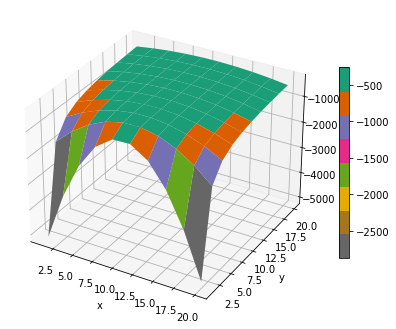

```python
fig = plt.figure(figsize=(7,7))
ax = fig.add_subplot(projection='3d')
surf = ax.plot_surface(X,Y,Z,cmap =cm.Dark2_r,linewidth=0,antialiased=True)
ax.set_xlabel("x")
ax.set_ylabel("y")
ax.set_zlabel("z")
fig.colorbar(surf, shrink=0.5, aspect=20)
```

```python
X_inside = np.array([[0,0,0],[0.2,0.2,0.2],[0.1, -0.1, -0.3]])

X_outside = np.array([[-1.2,0.3,-0.3],[0.8,-0.82,-0.9],[1, 0.6, -0.7],
                  [0.8,0.7,0.2],[0.7,-0.8,-0.45],[-0.3, 0.6, 0.9],
                  [0.7,-0.6,-0.8]])
X_all = np.vstack((X_inside,X_outside))
mu_vec = np.array([0,0])
cov_mat = np.array([[1,0],[0,1]])
X2D = np.random.multivariate_normal(mu_vec, cov_mat, 10000)
# X.shape
```

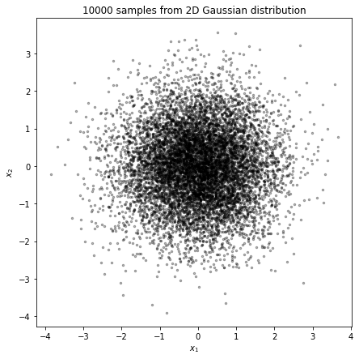

```python
%matplotlib inline
_,ax = plt.subplots(figsize=(7,7))
ax.scatter(X2D[:,0],X2D[:,1],color="black",alpha=.3,s=6)
ax.set_xlabel("$x_1$")
ax.set_ylabel("$x_2$")
ax.set_title("10000 samples from 2D Gaussian distribution")
```

```python
def chebyshevDistance(xi,xj):
    diff = np.abs(xi-xj)
    return np.max(diff,axis=1)
a = chebyshevDistance(np.array([0,0,0]),X_all)
```

```python
# distance
def distance0(x):
    def __distance0(xi):
        return x-xi
    return __distance0
# Chevishev distance
def distance1(x):
    def __distance1(xi):
        diff = np.abs(x-xi)
        res=  (np.max(diff,axis=1)).reshape(-1,1)
        return res
    return __distance1

# Euclidean distance
def distance3(x):
    def __distance3(xi):
        return np.sqrt(np.power(x-xi,2).sum(axis=1))
    return __distance3
```

```python
def windowFn(xs,unit_len=1):
    return np.invert(np.any( np.abs(xs) > (unit_len/2 ), axis=1 )).astype(int)


def fkn(X):
    return np.sum(windowFn(X))
#  P^
def parzenWindowEst(**kwargs):
    k  = kwargs.get('k',1)
    V  = kwargs.get('V',1)
    n  = kwargs.get('n',1)
    return (k/n*V)


def px_est(X,**kwargs):
    n = X.shape[0]
    h = kwargs.get('h',1)
    V = kwargs.get('V',1/np.sqrt(n))
    x = kwargs.get('center',np.zeros(X.shape[1]))
    k = np.sum(windowFn(distance1(x)(X)/h))
    p = parzenWindowEst(k=k,V=V,n=n)
    return p

# center = np.array([0,0,0])
# px_est(
#     X,
#     V      = 1,
#     h      = 1,
# )
```

```python
def gaussianKernel(X,**kwargs):
    center = kwargs.get('center',np.zeros(X.shape[1]))
    h      = kwargs.get('h',1)
    d      = X.shape[1]
    u      = distance3(center)(X)/h
    exp0   = 1/(( np.sqrt(2*np.pi))**d)
    exp1   = np.exp(-.5*(u**2))
    return exp0*exp1
def px_gaussian(X,**kwargs):
    V      = kwargs.get('V',1)
    center = kwargs.get('center',np.zeros(X.shape[1]))
    n      = X.shape[0]
    h      = kwargs.get('h',1)
    _X      = gaussianKernel(X,h=h,center=center)
    return np.sum((1/V)*(_X))/n
```

```python
xLen = np.linspace(-5, 5,100)
yLen = np.linspace(-5, 5,100)
X,Y = np.meshgrid(xLen,yLen)
XY  = np.array(list(zip(X,Y)))
result = []
for x in zipM(XY):
    x = np.array(x)
#     p = px_est(X2D,h=.1,V=1,center=x)
    p = px_gaussian(X2D,h=1,V=1,center=x)
    result.append(p)
Z = np.array(result).reshape(X.shape[0],X.shape[1])
# X.shape,Y.shape,Z.shape
```

```python
def densityplot():
    fig = plt.figure(figsize=(7,7))
    ax = fig.add_subplot(projection='3d')
    surf = ax.plot_surface(X,Y,Z,cmap =cm.Dark2_r,linewidth=0,antialiased=True,alpha=.7)
    ax.scatter(X2D[:,0],X2D[:,1],color="black")
    ax.set_xlabel("x")
    ax.set_ylabel("y")
    ax.set_zlabel("z")
    fig.colorbar(surf, shrink=0.5, aspect=20)
```

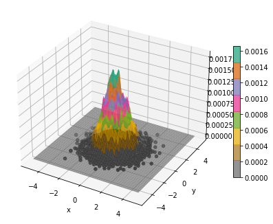

```python
densityplot()
```

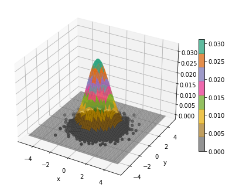

```python
densityplot()
```

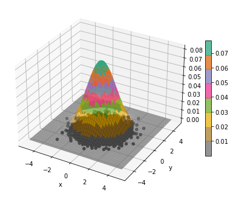

```python
densityplot()
```